# Minería y Análisis de Datos: Proyecto Final

Preparación de los Datos

Alejandra Lelo de Larrea Ibarra 000124433

Dante Ruiz Martínez 183340

José Carlos Escobar Gutiérrez 175895

```r
# Cargamos librerias
source('01_Libraries.R')
```

```r
# Cargamos funciones auxiliares
source('02_Utils.R')
```

# Selección de los datos

```r
# Cargamos los datos de entrenamiento obtenidos de la fase anterior.
datos_train<-readRDS('Datos_trad/train_trad.rds')

# Cargamos los catálogos de artículos y tiendas
datos_items<-readRDS('Datos_trad/datos_items.rds')
shops<-readRDS('Datos_trad/shops.rds')
```

Hasta el momento, se seleccionan todas las variables disponibles de la fase **Entendiendo los Datos**. Esta base de datos tiene las siguientes variables:

1. *date*: fecha en que se registró la compra/devolución en el formato dd/mm/yyyy.
2. *date_block_num*: número consecutivo para el mes de venta. Es decir, enero 2013 es igual a 0, febrero 2013 es igual a 1, …, octubre 2015 es igual a 33.
3. *shop_id*: identificador único de las tiendas de 1C.
4. *item_id*: identificador único del artículo.
5. *item_price*: precio en el que se vendió el artículo. No se menciona la moneda en que realizó la transacción, posiblemente fueron dólares o rublos rusos.
6. *item_cnt_day*: número de unidades vendidas del artículo. Números negativos indican una devolución del artículo. Se va a predecir una cantidad mensual de esta medida.
7. *item_name*: nombre del artículo (en ruso).
8. *item_category_id*: identificador único de la categoría a la que pertenece el artículo.
9. *item_category_name*: nombre de la categoría (en ruso).
10. *item_cateogry_id*: identificador único de la categoría.
11. *ID*: identificador único para la dupla (tienda,artículo).

Cabe destacar que las variables **item_name**, **item_category_name** y **shop_name**, correspondientes al nombre del artículo, nombre de la categoría y nombre de la tienda respectivamente, se conservan con fines de interpretabilidad, pero de ser necesario se eliminarán de las bases para acelerar el proceso y liberar memoria.

# Limpieza de datos

## Tipo de variables

Hechamos un vistazo a la base de datos obtenida del proceso de comprensión y exploración de los datos.

```r
glimpse(datos_train)
```

```
## Observations: 2,935,849
## Variables: 11
## $ date               <chr> "02.01.2013", "03.01.2013", "05.01.2013", "...
## $ date_block_num     <int> 0, 0, 0, 0, 0, 0, 0, 0, 0, 0, 0, 0, 0, 0, 0...
## $ shop_id            <int> 59, 25, 25, 25, 25, 25, 25, 25, 25, 25, 25,...
## $ item_id            <int> 22154, 2552, 2552, 2554, 2555, 2564, 2565, ...
## $ item_price         <dbl> 999.00, 899.00, 899.00, 1709.05, 1099.00, 3...
## $ item_cnt_day       <dbl> 1, 1, -1, 1, 1, 1, 1, 1, 1, 3, 2, 1, 1, 2, ...
## $ item_name          <chr> "Scene 2012 (BD)", "DEEP PURPLE The House O...
## $ item_category_id   <int> 37, 58, 58, 58, 56, 59, 56, 55, 55, 55, 55,...
## $ item_category_name <chr> "Cinema - Blu-ray", "Music - Vinyl", "Music...
## $ shop_name          <chr> "Yaroslavl shopping center &quot;Altair&quo...
## $ ID                 <int> 1329300, 153146, 153146, 153266, 153326, 15...
```

La variable *date* no es reconocida como fecha y la variable *tiem_cnt_day* no es reconocida como entero. Se hacen estos cambios.

```r
# Se cambia la variable date a formato fechay la variable item_cnt_day a formato entero
datos_train<-datos_train%>%
  mutate(date=as.Date(date,format="%d.%m.%Y"),
         item_cnt_day=as.integer(item_cnt_day))%>%
  select(date,everything())
```

## Datos faltantes

Checamos si existen datos faltantes en el set de entrenamiento.

```r
# Summary para detectar presencia de NA's
summary(datos_train)
```

```
##       date            date_block_num     shop_id      item_id
##  Min.   :2013-01-01   Min.   : 0.00   Min.   : 0   Min.   :    0
##  1st Qu.:2013-08-01   1st Qu.: 7.00   1st Qu.:22   1st Qu.: 4476
##  Median :2014-03-04   Median :14.00   Median :31   Median : 9343
##  Mean   :2014-04-03   Mean   :14.57   Mean   :33   Mean   :10197
##  3rd Qu.:2014-12-05   3rd Qu.:23.00   3rd Qu.:47   3rd Qu.:15684
##  Max.   :2015-10-31   Max.   :33.00   Max.   :59   Max.   :22169
##    item_price        item_cnt_day       item_name         item_category_id
##  Min.   :    -1.0   Min.   : -22.000   Length:2935849     Min.   : 0
##  1st Qu.:   249.0   1st Qu.:   1.000   Class :character   1st Qu.:28
##  Median :   399.0   Median :   1.000   Mode  :character   Median :40
##  Mean   :   890.9   Mean   :   1.243                      Mean   :40
##  3rd Qu.:   999.0   3rd Qu.:   1.000                      3rd Qu.:55
##  Max.   :307980.0   Max.   :2169.000                      Max.   :83
##  item_category_name  shop_name               ID
##  Length:2935849     Length:2935849     Min.   :     55
##  Class :character   Class :character   1st Qu.: 268563
##  Mode  :character   Mode  :character   Median : 560612
##                                        Mean   : 611868
##                                        3rd Qu.: 941088
##                                        Max.   :1330166
```

No se tienen valores faltantes en ninguna variable del set de entrenamiento.

## Valores únicos por variable.

Se verifican los valores únicos por variable para ver si existen observaciones con errores o si vale la pena categorizar alguna variable.

Para las variables *date*, *date_block_num*, *shop_id*, *item_id*, *item_name*,*item_category_id*, *item_category_name*, *shop_name* y *ID* no es necesario realizar esta prueba ya se son identificadores únicos de fecha, tienda, categoría o artículo.

Las variables que sí se deben revisar son *item_price* y *item_cnt_day*.

### Precio por artículo

```r
length(unique(datos_train$item_price))
```

```
## [1] 19993
```

Para la variable *item_price* se tienen 19,993 precios únicos. Esto no es sorpresa ya que la variable es de tipo double. Veamos un summary de esta variable para poder decidir sobre su distribución y posible categorización.

```r
summary(datos_train$item_price)
```

```
##     Min.  1st Qu.   Median     Mean  3rd Qu.     Max.
##     -1.0    249.0    399.0    890.9    999.0 307980.0
```

En primer lugar, se puede notar que existen precios negativos, lo cual no es factible. En segundo lugar la diferencia entre el tercer cuantil y el máximo es muy grande, esto es señal de un dato atípico.

Veamos los 20 valores más grandes del precio de los artículos.

```r
head(sort(datos_train$item_price,decreasing = TRUE),20)
```

```
##  [1] 307980  59200  50999  49782  42990  42990  42990  42990  42000  41990
## [11]  41990  41990  40991  40900  37991  37991  36990  36990  36990  36990
```

Efectivamente se trata de un valor atípico. Veamos de qué producto se trata.

```r
datos_train$item_name[which(datos_train$item_price==307980)]
```

```
## [1] "Radmin 3 - 522 persons."
```

Investigando en el catálogo de 1C y, asumiendo que el precio está en dólares, se llegó a la conclusión de que se escribó mal el precio de este artículo y sería razonable pensar que el verdadero precio es de $3,079.80 dólares. Por lo tanto, se sustitye dicho valor.

```r
datos_train$item_price[which(datos_train$item_price==307980)]<-3079.80
```

En cuanto a los precios negativos, veamos cuantos son.

```r
length(which(datos_train$item_price<0))
```

```
## [1] 1
```

Sólo se tiene un artículo que tiene precio negativo. Busquemos si en la misma fecha se vendió el mismo artículo para extraer el verdadero precio.

```r
# extraemos los items devueltos
item_id_pneg<-datos_train%>%
  filter(item_price<0)%>%
  select(item_id)%>%
  unique()%>%
  as.numeric

# extraemos la fecha de devolucion
date_pneg<-datos_train%>%
  filter(item_price<0)%>%
  select(date)%>%
  unique()

# Extraemso el precio promedio del objeto en la misma fecha
items_ppos<-datos_train%>%
  filter(item_id==item_id_pneg)%>%
  filter(date==date_pneg)%>%
  filter(item_price!=-1)%>%
  select(date, item_name, item_price)

datatable(items_ppos)
```

|  | date | item_name | item_price |
| --- | --- | --- | --- |
| 1 | 2013-05-15 | DmC Devil May Cry [PS3, Russian subtitles] | 1249.5 |
| 2 | 2013-05-15 | DmC Devil May Cry [PS3, Russian subtitles] | 1249.5 |
| 3 | 2013-05-15 | DmC Devil May Cry [PS3, Russian subtitles] | 1249 |

Se tienen otros tres artículos iguales vendidos en la misma fecha. Por lo tanto se reemplaza el precio negativo con el promedio del precio de estos artículos.

```r
# Reemplazamos el precio -1 con el promedio
datos_train$item_price[which(datos_train$item_price==-1)]<-mean(items_ppos$item_price)
```

Veamos como quedó la distribución del precio de los articulos.

```r
# Resúmen del precio del artículo
summary(datos_train$item_price)
```

```
##     Min.  1st Qu.   Median     Mean  3rd Qu.     Max.
##     0.07   249.00   399.00   890.75   999.00 59200.00
```

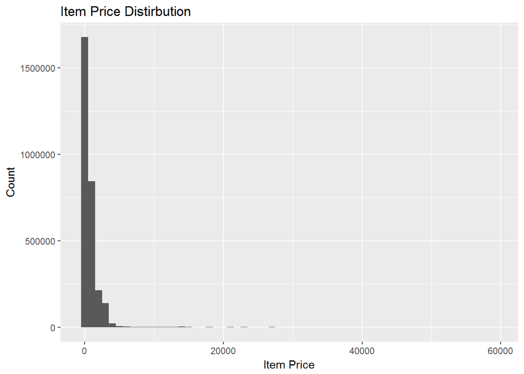

```r
# Histograma del precio de los artículos.
ggplot(datos_train,aes(item_price))+
  geom_histogram(binwidth = 1000)+
  ggtitle('Item Price Distirbution')+
  xlab('Item Price')+
  ylab('Count')
```

Todavía existe una gran diferencia entre el tercer cuantil y el valor máximo del precio. Sin embargo, dado que la tarea es predecir el número de articulos vendidos cada mes, de cada tipo, en cada tienda; por el momento, no se realiza ninguna estrategia de categorización del precio. De ser necesario, se realizará en el pipeline de python al modelar.

### Número de unidades vendidas/devueltas.

Verificamos los valores únicos para la variable *item_cnt_day*.

```r
sort(unique(datos_train$item_cnt_day),decreasing = TRUE)
```

```
##   [1] 2169 1000  669  637  624  539  533  512  508  504  502  501  500  480
##  [15]  412  405  401  343  325  313  300  299  288  264  255  251  242  240
##  [29]  231  230  222  217  207  205  200  195  194  187  179  171  168  167
##  [43]  164  163  161  157  156  154  153  151  150  149  148  147  146  145
##  [57]  142  140  139  138  135  134  133  132  131  130  129  128  127  126
##  [71]  124  121  118  117  116  115  114  113  112  111  110  109  108  107
##  [85]  106  105  104  103  102  101  100   99   98   97   96   95   93   92
##  [99]   91   90   89   88   87   86   85   84   83   82   81   80   79   78
## [113]   77   76   75   74   73   72   71   70   69   68   67   66   65   64
## [127]   63   62   61   60   59   58   57   56   55   54   53   52   51   50
## [141]   49   48   47   46   45   44   43   42   41   40   39   38   37   36
## [155]   35   34   33   32   31   30   29   28   27   26   25   24   23   22
## [169]   21   20   19   18   17   16   15   14   13   12   11   10    9    8
## [183]    7    6    5    4    3    2    1   -1   -2   -3   -4   -5   -6   -9
## [197]  -16  -22
```

El número de unidades vendidas por artículo va desde 1 hasta 2169. El número de unidades devueltas por artículo va desde 1 hasta 22. No parece haber nada incorrecto en esta variable.

Veamos que artículos fueron los más vendidos.

```r
cnt_day_mayores<-sort(unique(datos_train$item_cnt_day),decreasing = TRUE)[1:10]

datos_train$item_name[match(cnt_day_mayores,datos_train$item_cnt_day)]
```

```
##  [1] "Delivery to the point of delivery (Boxberry)"
##  [2] "Corporate package undershirt 1C Interest white (34 * 42) 45 microns"
##  [3] "Ticket &quot;IgroMir 2015&quot; - October 3, 2015 (website) [Digital version]"
##  [4] "Ticket &quot;IgroMir 2015&quot; - October 3, 2015 (website) UPR [Digital version]"
##  [5] "Grand Theft Auto V [PC, Russian subtitles]"
##  [6] "Delivery to the point of delivery (Boxberry)"
##  [7] "Ticket &quot;IgroMir 2015&quot; - October 3, 2015 (website) UPR [Digital version]"
##  [8] "Ticket &quot;IgroMir 2014&quot; (for one day (separately - October 4, 5, 2014))"
##  [9] "Middle-earth: Shadow of Mordor [PC, Digital Edition]"
## [10] "Ticket &quot;IgroMir 2015&quot; - October 3, 2015 (website) [Digital version]"
```

# Ingeniería de características

Para hacer el feature engineering nos olivdamos de los nombres de los artículos, categorías y tiendas de tal forma que sólo trabajaremos con el identificador de la tienda, el identificador del artículo, la fecha, el consecutivo de la fecha, el precio y las ventas. Esto por motivos del uso de memoria en R.

## Separar día mes y año

De la variable *date* se puede separar el día, mes y año. Esto será de utilidad para los agregados mensuales.

```r
datos_train<-datos_train%>%
  dplyr::select(date,date_block_num,shop_id,item_id,item_price,item_cnt_day)%>%
  mutate(day=as.integer(substring(as.character(date),9,10)),
         month=as.integer(substring(as.character(date),6,7)),
         year=as.integer(substring(as.character(date),1,4)))%>%
  select(date,day,month,year,everything())
```

Verifiquemos que tengamos del 2013 al 2015 en la muestra.

```r
unique(datos_train$year)
```

```
## [1] 2013 2014 2015
```

## Agregados Mensuales

La tarea es predecir las ventas mensuales por dupla (tienda, artículo); por lo tanto, se hace un agregado mensual de las variables.

El número de artículos vendidos, **item_cnt_day**, se agrega calculando la suma de todos los artículos vendidos en el mismo mes, en la misma tienda.

El precio del artículo vendido, **item_price**, se agrega calculando el precio promedio de todos los artículos vendidos en el mismo mes, en la misma tienda.

```r
# hacemos el agregado mensual por dupla (tienda,art) y fecha mensual (date_block_num)
train_mensuales<-datos_train%>%
  group_by(date_block_num,shop_id,item_id)%>%
  summarise(item_price_mean=mean(item_price),
            item_cnt_month=sum(item_cnt_day))

# Ordenaos por dupla
train_mensuales<-arrange(train_mensuales,date_block_num,shop_id,item_id)

# eliminar datos train para liberar memoria
mem_change(rm(datos_train))
```

```
## -35.2 MB
```

Hechamos un vistazo a los datos mensuales

```r
glimpse(train_mensuales)
```

```
## Observations: 1,609,124
## Variables: 5
## $ date_block_num  <int> 0, 0, 0, 0, 0, 0, 0, 0, 0, 0, 0, 0, 0, 0, 0, 0...
## $ shop_id         <int> 0, 0, 0, 0, 0, 0, 0, 0, 0, 0, 0, 0, 0, 0, 0, 0...
## $ item_id         <int> 32, 33, 35, 43, 51, 61, 75, 88, 95, 96, 98, 11...
## $ item_price_mean <dbl> 221.0, 347.0, 247.0, 221.0, 128.5, 195.0, 76.0...
## $ item_cnt_month  <int> 6, 3, 1, 1, 2, 1, 1, 1, 1, 1, 25, 1, 3, 1, 1, ...
```

Un problema es que hay duplas (tienda, artículo) para las cuales no hay registro en algunos meses. Es decir, no en todos los meses del año se vendieron todos los artículos en todas las tiendas. Por lo tanto, no se tienen las series de tiempo completas. Para resolver este problema, vamos a completar dichas series de tal manera que el algoritmo sea capaz de aprender las irregularidades en las ventas de 1C.

## Completar series de tiempo por dupla (tienda, artículo)

Creamos el grid con todas las posibles combinaciones de mes, tienda y artículo.

```r
#Creamos grid de date_block_num, shop_id, item_id
# train_mensuales_completo<-list(date_block_num=0:33,
#                                shop_id=unique(shops$shop_id),
#                                item_id=unique(datos_items$item_id))%>%
#   expand.grid
#
# dim(train_mensuales_completo)

train_mensuales_completo <- read_csv("Datos_clean/grid.csv")
```

Tendremos $10,913,850$ observaciones en la base de datos. Hacemos un merge de los datos mensuales observados obtenidos en el paso anterior con este grid.

```r
# Hacemos left join de los datos mensuales
train_mensuales_completo<-left_join(train_mensuales_completo,train_mensuales,by=c('date_block_num','shop_id','item_id'))

mem_change(rm(train_mensuales))
```

```
## -45.2 MB
```

Agregamos el item_category_id para poder hacer agregaciones de precios por categorías de artículos.

```r
# Agregamos la variable category_id
train_mensuales_completo<-train_mensuales_completo%>%
  left_join(datos_items,key='item_id')%>%
  select(-c(item_name,item_category_name))
```

Vemos los datos mensuales

```r
glimpse(train_mensuales_completo)
```

```
## Observations: 10,913,850
## Variables: 6
## $ shop_id          <int> 59, 59, 59, 59, 59, 59, 59, 59, 59, 59, 59, 5...
## $ item_id          <int> 22154, 2552, 2554, 2555, 2564, 2565, 2572, 25...
## $ date_block_num   <int> 0, 0, 0, 0, 0, 0, 0, 0, 0, 0, 0, 0, 0, 0, 0, ...
## $ item_price_mean  <dbl> 999, NA, NA, NA, NA, NA, NA, NA, 399, NA, NA,...
## $ item_cnt_month   <int> 1, NA, NA, NA, NA, NA, NA, NA, 2, NA, NA, NA,...
## $ item_category_id <int> 37, 58, 58, 56, 59, 56, 55, 55, 55, 55, 55, 5...
```

Unicamente tenemos missings en item_price_mean y item_cnt_month. Los missings en item_cnt_month corresponden a que no hubo ventas para ese artículo, en ese mes, en esa tienda; porlo tanto, sustituimos estos NA’s con 0.

```r
train_mensuales_completo$item_cnt_month[which(is.na(train_mensuales_completo$item_cnt_month))]<-0
```

Para arreglar los NA’s del precio, hacemos nuevas variables. Calculamos: * el precio promedio por artículo (*item_price_mean_art*), * la cantidad vendida por artículo (*item_cnt_art*), * la cantidad vendida promedio por artículo (*item_cnt_mean_art*), * el precio promedio por categoría (*item_price_mean_cat*), * la cantidad vendida por categoría (*item_cnt_cat*), * la cantidad vendida promedio por categoría (*item_cnt_mean_art*), * el precio promedio por tienda (*item_price_mean_shop*), * la cantidad vendida por tienda (*item_cnt_shop*), * la cantidad vendida promedio por tienda (*item_cnt_mean_art*),

```r
# Por artículo
mean_price_item<-train_mensuales_completo%>%
  group_by(item_id)%>%
  summarise(item_price_mean_art=mean(item_price_mean,na.rm=TRUE),
            item_cnt_art=sum(item_cnt_month),
            item_cnt_mean_art=mean(item_cnt_month,na.rm=TRUE))


# Por categoria
mean_price_cat<-train_mensuales_completo%>%
  group_by(item_category_id)%>%
  summarise(item_price_mean_cat=mean(item_price_mean,na.rm=TRUE),
            item_cnt_cat=sum(item_cnt_month),
            item_cnt_mean_cat=mean(item_cnt_month,na.rm=TRUE))

# Por tienda
mean_price_shop<-train_mensuales_completo%>%
  group_by(shop_id)%>%
  summarise(item_price_mean_shop=mean(item_price_mean,na.rm=TRUE),
            item_cnt_shop=sum(item_cnt_month),
            item_cnt_mean_shop=mean(item_cnt_month,na.rm=TRUE))
```

Ahora hacemos un left join de estos nuevos precios con el data set completo

```r
# Juntamos los distintos precios
train_mensuales_completo<-train_mensuales_completo%>%
  left_join(mean_price_item, key='item_id')%>%
  left_join(mean_price_cat, key='item_category_id')%>%
  left_join(mean_price_shop,key='shop_id')
# Liberamos memoria
mem_change(rm(mean_price_item))
```

```
## -611 kB
```

```r
mem_change(rm(mean_price_cat))
```

```
## -2.47 kB
```

```r
mem_change(rm(mean_price_shop))
```

```
## -1.8 kB
```

Ya solo tenemos NA’s en el precio promedio original y en el precio promedio por artículo. El primero no se va a utilizar ya que sólo sirvió para construir el resto de las características. En cuanto al segundo, se imputa con la mediana debido a la existencia de datos atípicos en el precio.

```r
# Eliminamos variable item_price_mean
train_mensuales_completo<-train_mensuales_completo%>%
  dplyr::select(-item_price_mean)

# Imputamos con la mediana los NA's del precio pormedio por artículo.
train_mensuales_completo$item_price_mean_art[which(is.na(train_mensuales_completo$item_price_mean_art))]<-median(train_mensuales_completo$item_price_mean_art,na.rm=TRUE)
```

## Rezagos de las variables

```r
# Creamos lags de variables.
train_mensuales_completo<-train_mensuales_completo%>%
  mutate(item_price_mean_art_l1=lag(item_price_mean_art),
         item_price_mean_art_l2=lag(item_price_mean_art,2),
         item_price_mean_art_l3=lag(item_price_mean_art,3),
         item_price_mean_art_l6=lag(item_price_mean_art,6),
         #item_price_mean_art_l12=lag(item_price_mean_art,12),
         item_cnt_art_l1=lag(item_cnt_art),
         item_cnt_art_l2=lag(item_cnt_art,2),
         item_cnt_art_l3=lag(item_cnt_art,3),
         item_cnt_art_l6=lag(item_cnt_art,6),
         #item_cnt_art_l12=lag(item_cnt_art,12),
         item_cnt_mean_art_l1=lag(item_cnt_mean_art),
         item_cnt_mean_art_l2=lag(item_cnt_mean_art,2),
         item_cnt_mean_art_l3=lag(item_cnt_mean_art,3),
         item_cnt_mean_art_l6=lag(item_cnt_mean_art,6),
         #item_cnt_mean_art_l12=lag(item_cnt_mean_art,12),
         item_price_mean_cat_l1=lag(item_price_mean_cat),
         item_price_mean_cat_l2=lag(item_price_mean_cat,2),
         item_price_mean_cat_l3=lag(item_price_mean_cat,3),
         item_price_mean_cat_l6=lag(item_price_mean_cat,6),
         #item_price_mean_cat_l12=lag(item_price_mean_cat,12),
         item_cnt_cat_l1=lag(item_cnt_cat),
         item_cnt_cat_l2=lag(item_cnt_cat,2),
         item_cnt_cat_l3=lag(item_cnt_cat,3),
         item_cnt_cat_l6=lag(item_cnt_cat,6),
         #item_cnt_cat_l12=lag(item_cnt_cat,12),
         item_cnt_mean_art_l1=lag(item_cnt_mean_art),
         item_cnt_mean_art_l2=lag(item_cnt_mean_art,2),
         item_cnt_mean_art_l3=lag(item_cnt_mean_art,3),
         item_cnt_mean_art_l6=lag(item_cnt_mean_art,6),
         #item_cnt_mean_art_l12=lag(item_cnt_mean_art,12),
         item_price_mean_shop_l1=lag(item_price_mean_shop),
         item_price_mean_shop_l2=lag(item_price_mean_shop,2),
         item_price_mean_shop_l3=lag(item_price_mean_shop,3),
         item_price_mean_shop_l6=lag(item_price_mean_shop,6),
         #item_price_mean_shop_l12=lag(item_price_mean_shop,12),
         item_cnt_shop_l1=lag(item_cnt_shop),
         item_cnt_shop_l2=lag(item_cnt_shop,2),
         item_cnt_shop_l3=lag(item_cnt_shop,3),
         item_cnt_shop_l6=lag(item_cnt_shop,6),
         #item_cnt_shop_l12=lag(item_cnt_shop,12),
         item_cnt_mean_shop_l1=lag(item_cnt_mean_shop),
         item_cnt_mean_shop_l2=lag(item_cnt_mean_shop,2),
         item_cnt_mean_shop_l3=lag(item_cnt_mean_shop,3),
         item_cnt_mean_shop_l6=lag(item_cnt_mean_shop,6))
         #item_cnt_mean_shop_l12=lag(item_cnt_mean_shop,12),
```

Al generar un rezago de tamaño $n$ se obtienene $n$ valores faltantes. Imputamos los NA’s de los rezagos (primeros $n$ valores para rezago de tamaño $n$ en cada variable) con el primer valor observado (correspondiente a la observación $n+1$).

```r
# Imputamos valores
train_mensuales_completo<-apply(train_mensuales_completo,2,imputarLags)
```

# Almacenamiento de la base de datos limpia y completa

Por último, se almacena en la carpeta **Datos_clean** la base de datos limpia, con las series de tiempo completas y la ingeniería de características.

```r
#saveRDS(train_mensuales_completo,"Datos_clean/train_mensuales_completo.rds")
write.csv(train_mensuales_completo,"Datos_clean/train_mensuales_completo.csv")
```

```r
t<-t-Sys.time()

t
```

```
## Time difference of -2.480928 secs
```